# Final Extra Credit

2023-05-08

## Extra-Credit Work

### Math 264, Spring 2023

#1 Thoroughly describe and display a quantitative data set. Be sure to mention center, spread, shape, and possibly outliers; include boxplot and histogram.

We may make some observations: 1. Verbal and Math scores seem to be correlated and normally distributed. 2. Height and Shoe seem to be correlated and right-skewed 3. TV time and Computer time seem to be correlated and right-skewed 4. Dad Height and Mom Height seem to be correlated and normal 5. Dad Age and Mom Age seem to be correlated and normal 6. Exercise is right skewed 7. Siblings is right skewed 8. Age is right skewed 9. Credits is left skewed

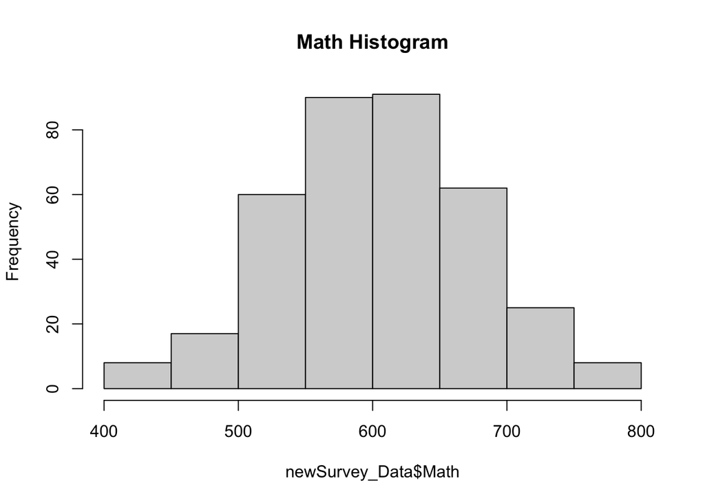

```r
newSurvey_Data<-read.csv("~/Downloads/newSurvey_Data.csv")
hist(newSurvey_Data$Math, main="Math Histogram")
```

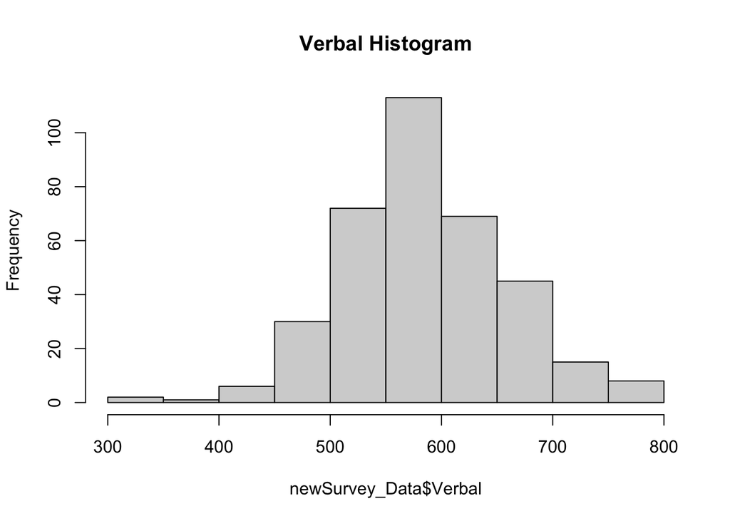

```r
hist(newSurvey_Data$Verbal, main="Verbal Histogram")
```

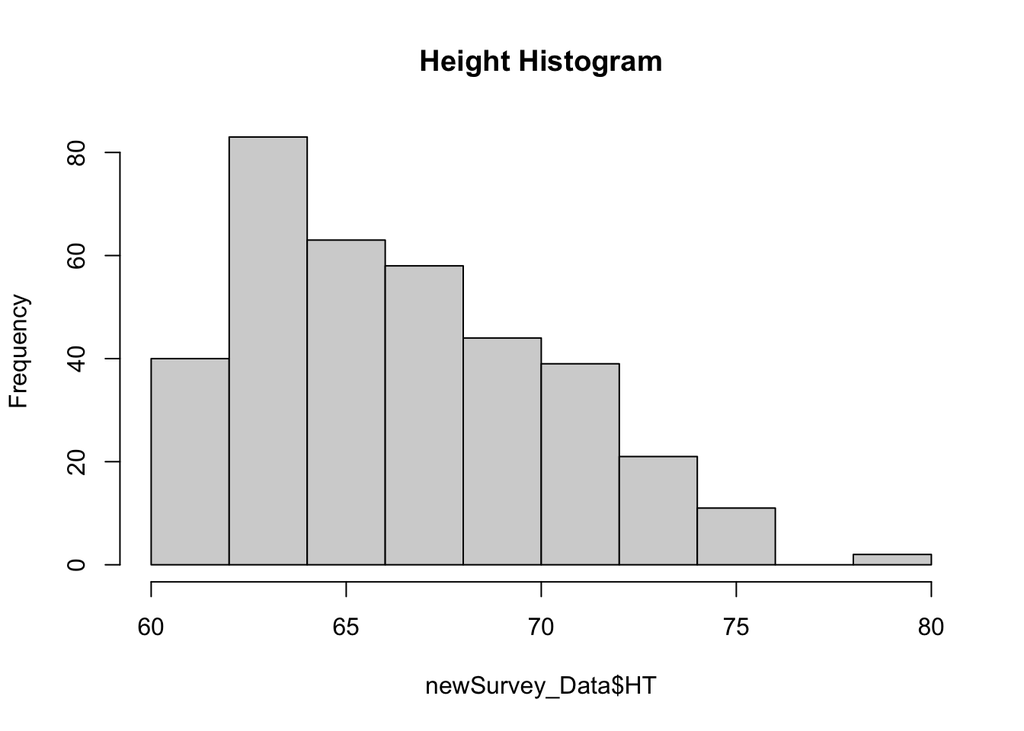

```r
hist(newSurvey_Data$HT, main="Height Histogram")
```

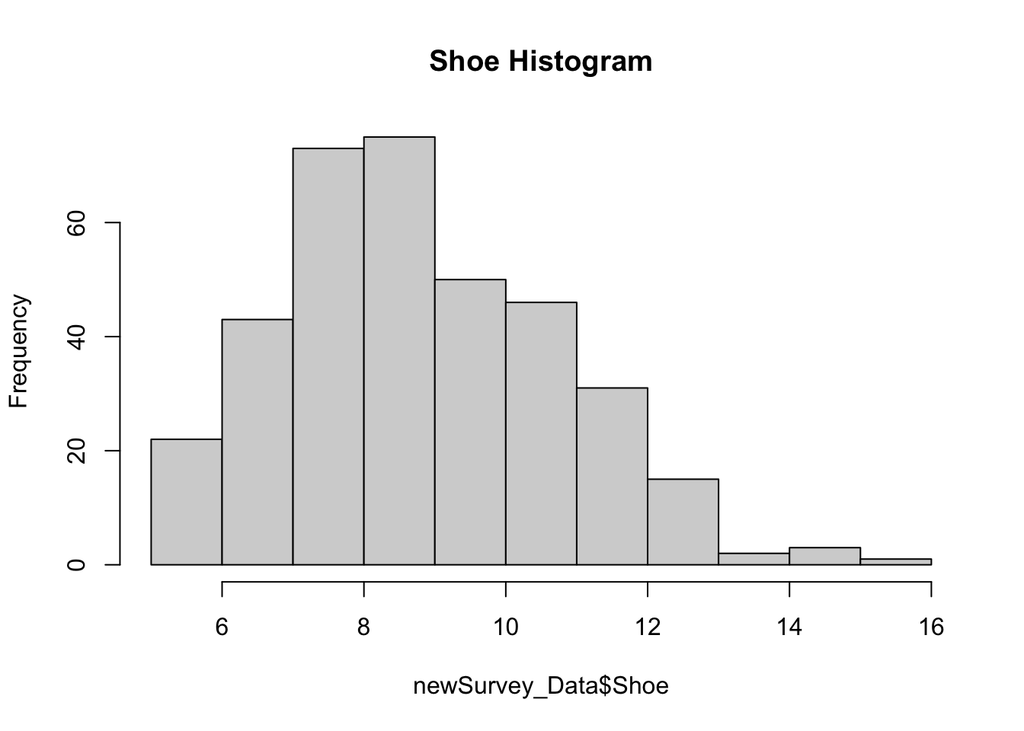

```r
hist(newSurvey_Data$Shoe, main="Shoe Histogram")
```

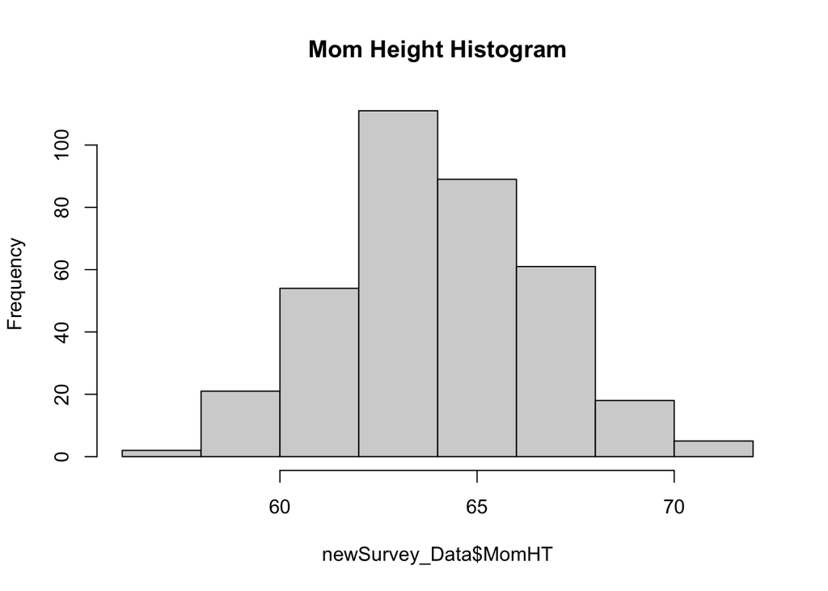

```r
hist(newSurvey_Data$MomHT, main="Mom Height Histogram")
```

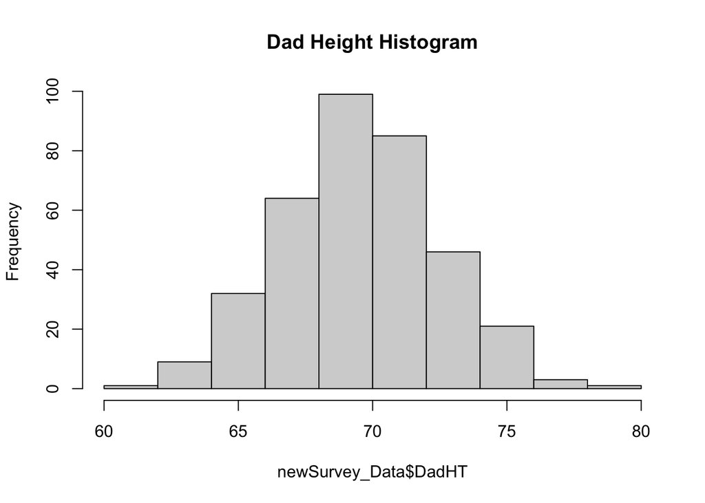

```r
hist(newSurvey_Data$DadHT, main="Dad Height Histogram")
```

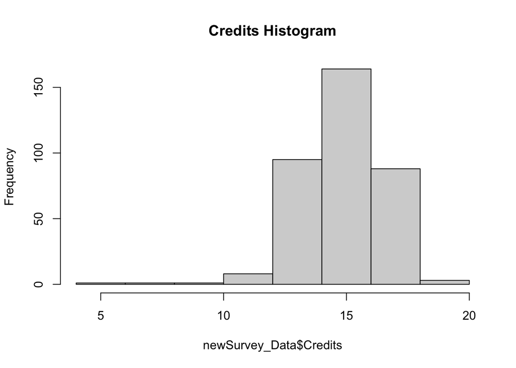

```r
hist(newSurvey_Data$Credits, main="Credits Histogram")
```

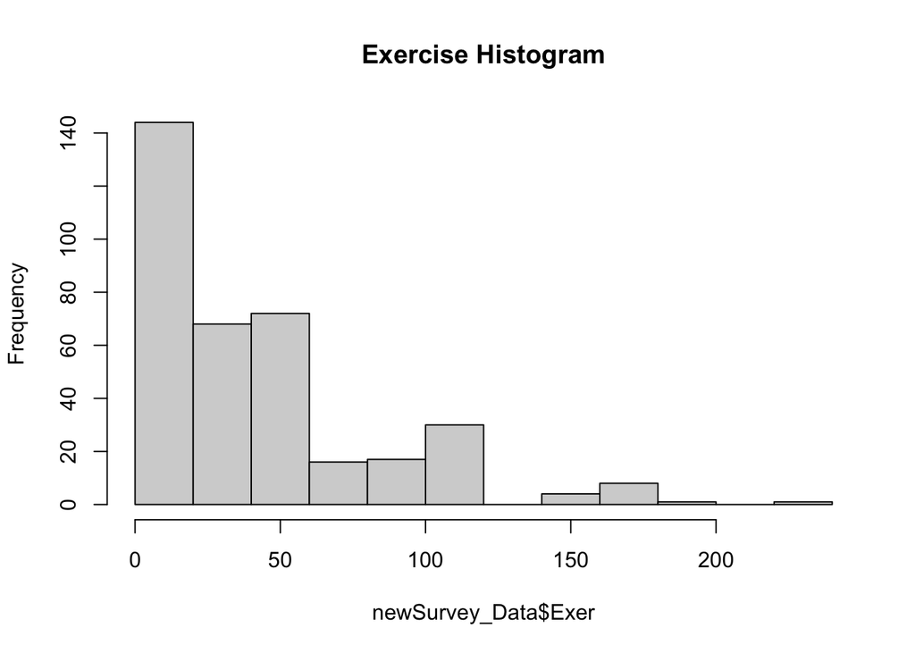

```r
hist(newSurvey_Data$Exer, main="Exercise Histogram")
```

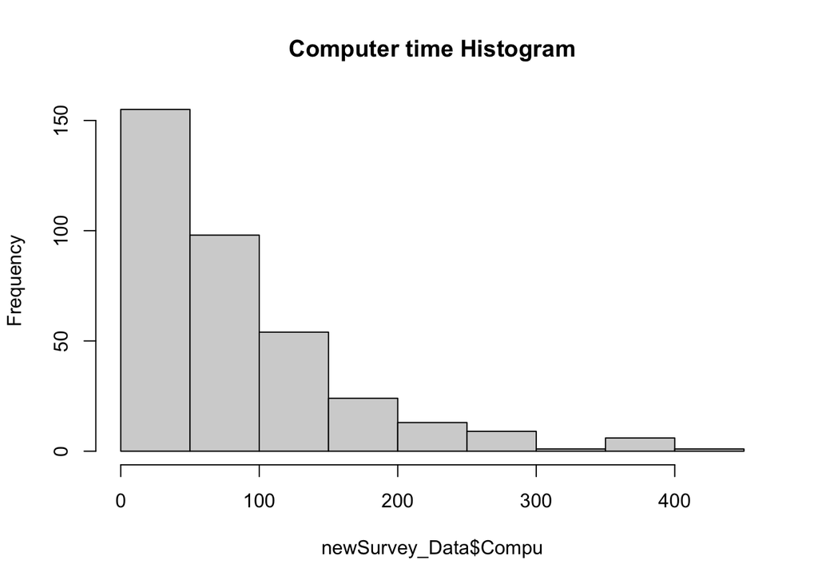

```r
hist(newSurvey_Data$Compu, main="Computer time Histogram")
```

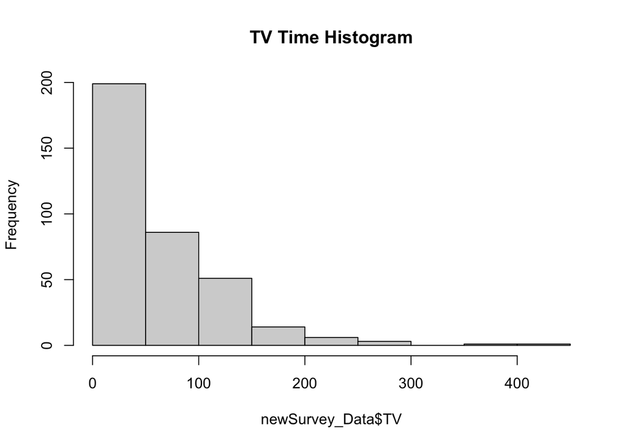

```r
hist(newSurvey_Data$TV, main="TV Time Histogram")
```

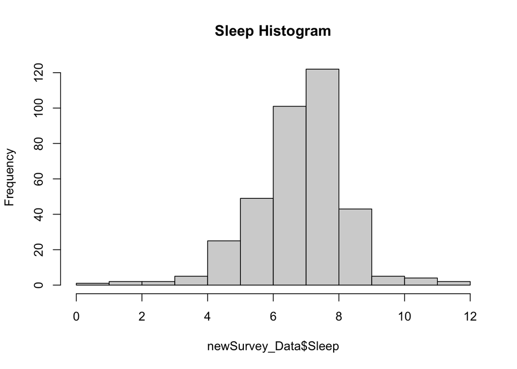

```r
hist(newSurvey_Data$Sleep, main="Sleep Histogram")
```

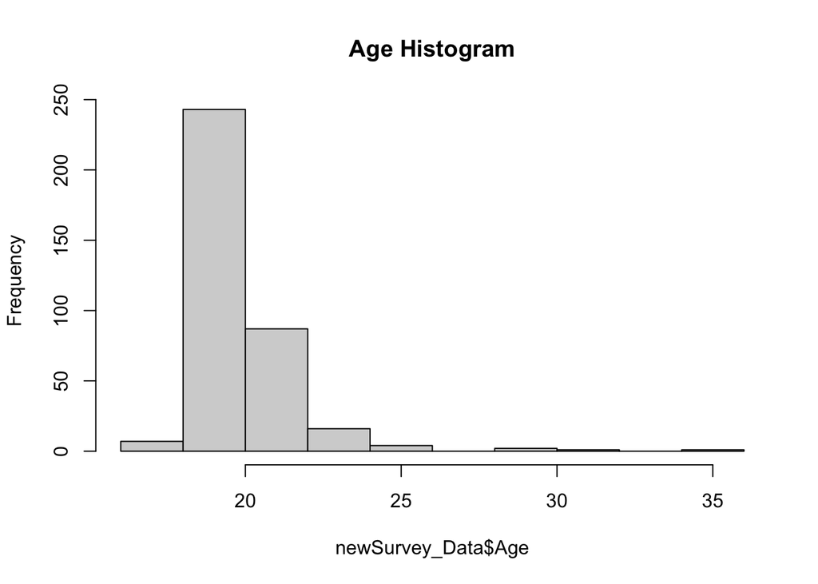

```r
hist(newSurvey_Data$Age, main="Age Histogram")
```

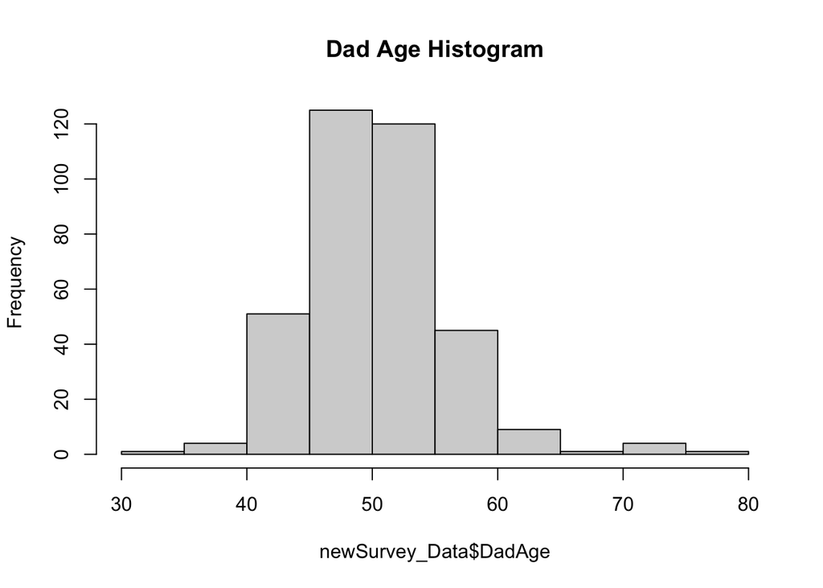

```r
hist(newSurvey_Data$DadAge, main="Dad Age Histogram")
```

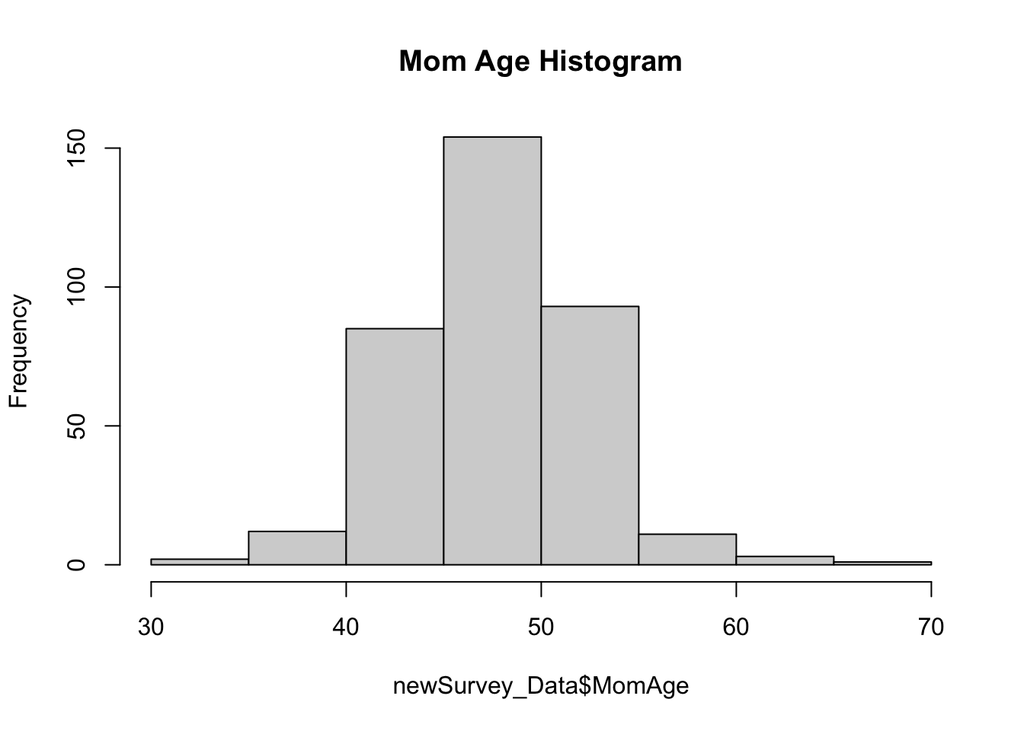

```r
hist(newSurvey_Data$MomAge, main="Mom Age Histogram")
```

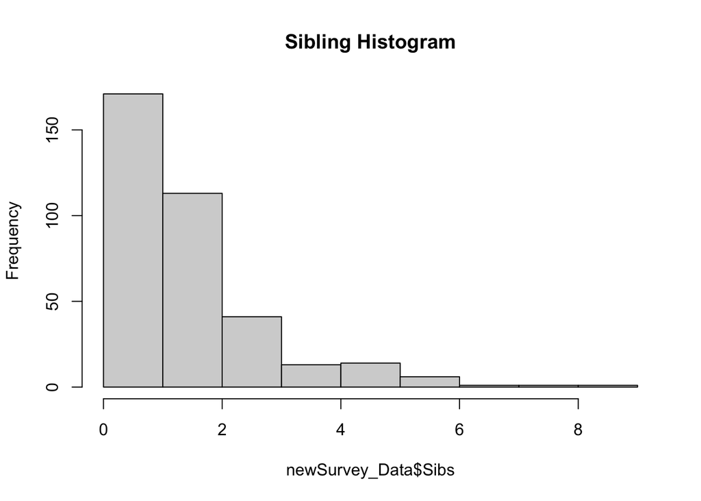

```r
hist(newSurvey_Data$Sibs, main="Sibling Histogram")
```

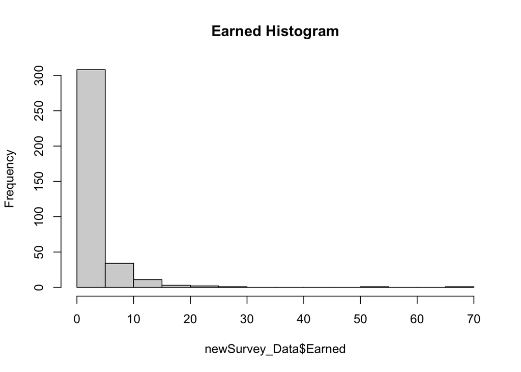

```r
hist(newSurvey_Data$Earned, main="Earned Histogram")
```

Note: In a true analysis, and if we were building a model for the pure goal of predicting rather than understanding the data, we may use PCA to combine those variables defined above that have a dependence relationship. Here is some sample code of using PCA for the Math and Verbal Scores:

```r
#install.packages("factoextra")
library(factoextra)
# Perform PCA
numerical_data<-data.frame(newSurvey_Data$Math, newSurvey_Data$Verbal)
data_normalized <- scale(numerical_data)
pca <- prcomp(data_normalized, scale = TRUE)

# summarize results
summary(pca)
```

```
## Importance of components:
##                           PC1    PC2
## Standard deviation     1.1711 0.7929
## Proportion of Variance 0.6857 0.3143
## Cumulative Proportion  0.6857 1.0000
```

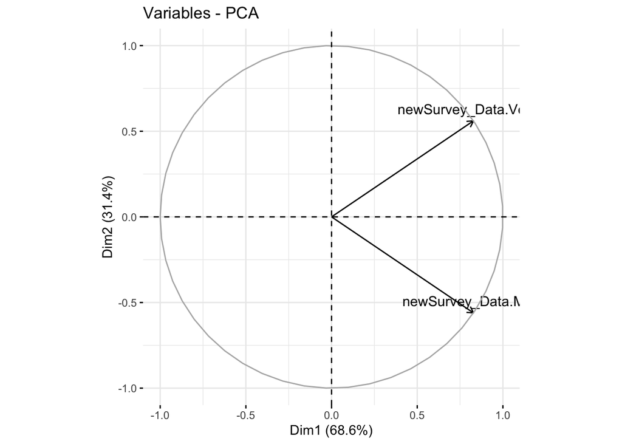

```r
# Create a biplot of the PCA results
fviz_pca_var(pca, col.var = "black")
```

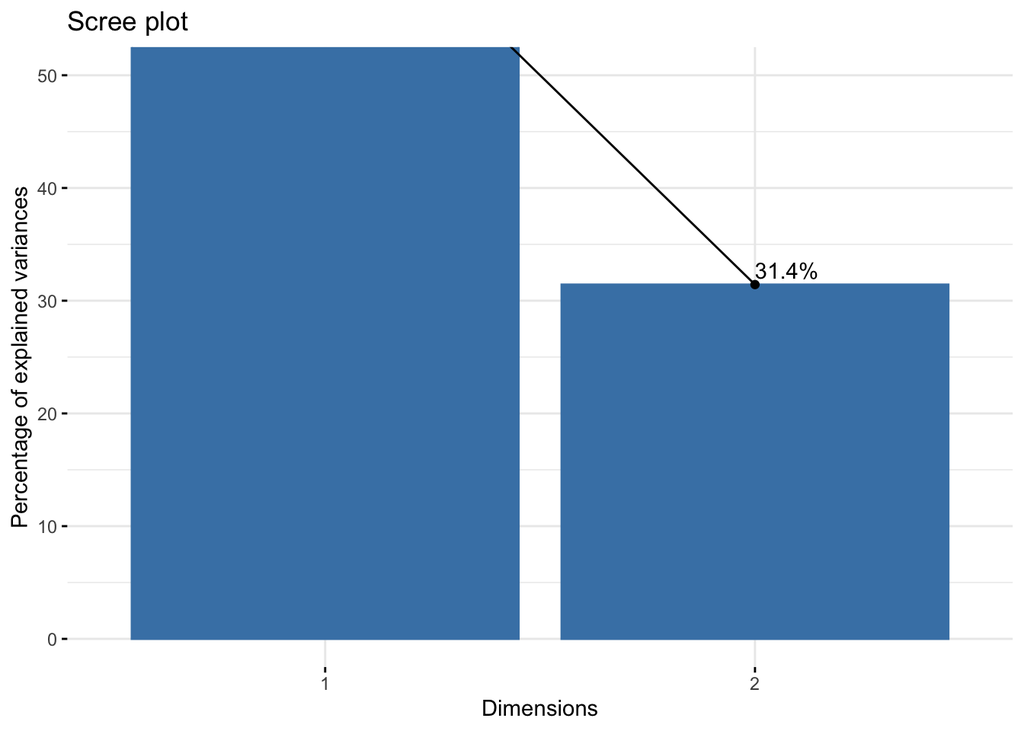

```r
fviz_eig(pca, addlabels = TRUE, ylim = c(0, 50))
```

from our summary, we see that the first principle component accounts for 68% of the total variance. this implies almost two-thirds of the data between verbal and math scores may be represented by just the first principal component.

```r
# Perform PCA
numerical_data_2<-data.frame(newSurvey_Data$DadHT, newSurvey_Data$MomHT, newSurvey_Data$MomAge, newSurvey_Data$DadAge)
data_normalized_2 <- scale(numerical_data_2)
pca_2 <- prcomp(data_normalized_2, scale = TRUE)

# summarize results
summary(pca_2)
```

```
## Importance of components:
##                           PC1    PC2    PC3     PC4
## Standard deviation     1.3143 1.1298 0.8511 0.52133
## Proportion of Variance 0.4319 0.3191 0.1811 0.06795
## Cumulative Proportion  0.4319 0.7510 0.9321 1.00000
```

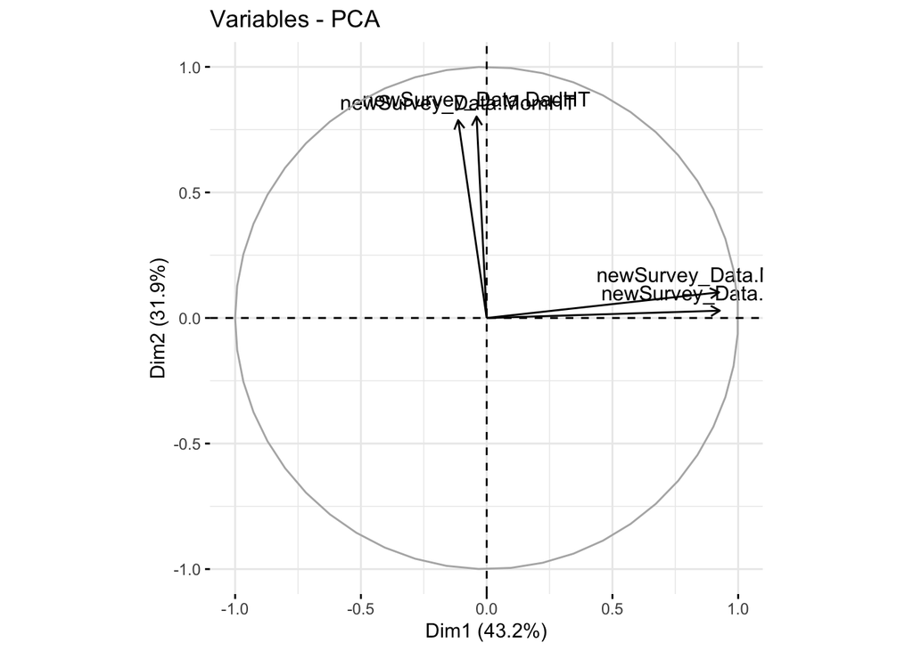

```r
# Create a biplot of the PCA results
fviz_pca_var(pca_2, col.var = "black")
```

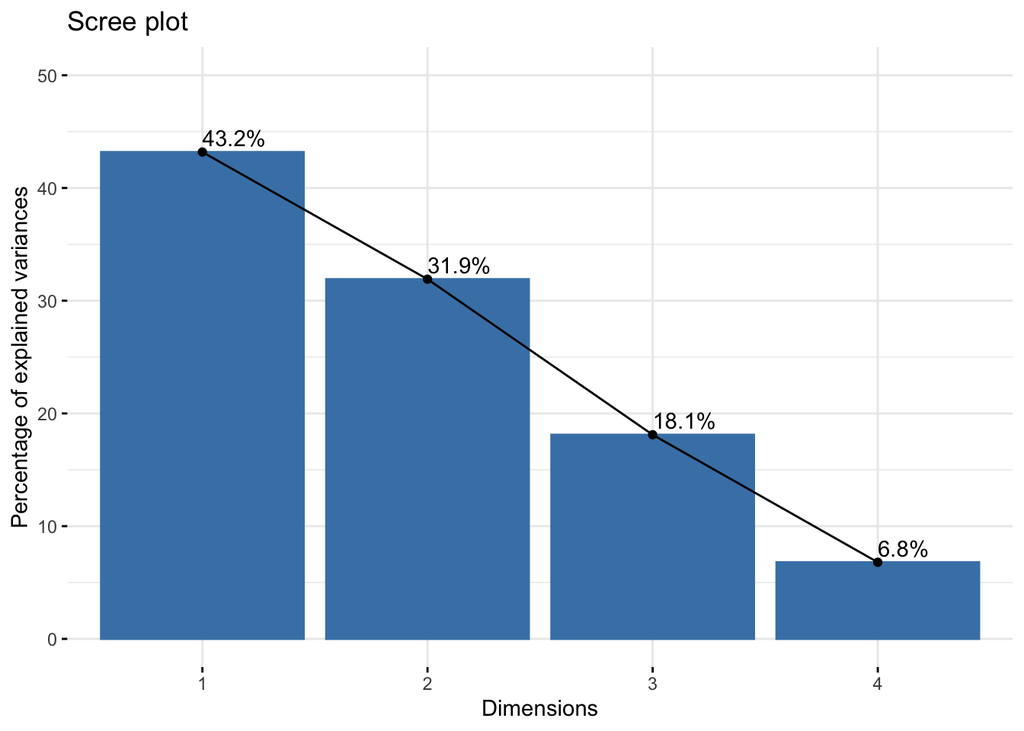

```r
fviz_eig(pca_2, addlabels = TRUE, ylim = c(0, 50))
```

Given our PCA analysis, we would only need to use three dimensions for these variables, since we would capture 93.2% of the information by the first three components.

#2 Compare values of a quantitative variable for 2 or more groups. Be sure to compare centers, spreads, and shapes; include side-by-side boxplots or side-by-side histograms. Here we will compare values for Verbal and Math scores:

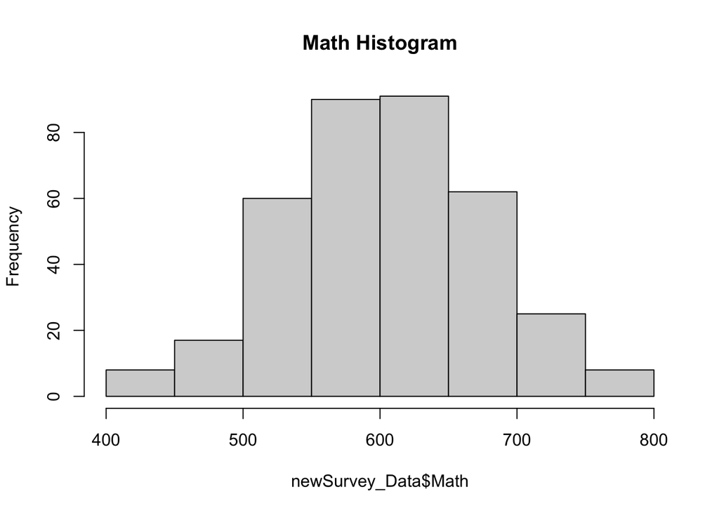

```r
hist(newSurvey_Data$Math, main="Math Histogram")
```

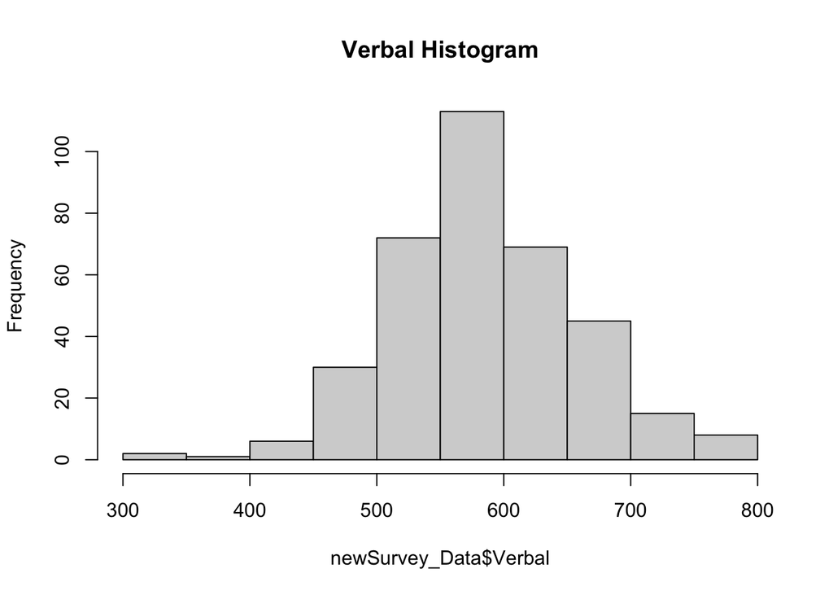

```r
hist(newSurvey_Data$Verbal, main="Verbal Histogram")
```

```r
sd(newSurvey_Data$Math)
```

```
## [1] 71.8319
```

```r
sd(newSurvey_Data$Verbal)
```

```
## [1] 73.3779
```

```r
mean(newSurvey_Data$Math)
```

```
## [1] 611.6343
```

```r
mean(newSurvey_Data$Verbal)
```

```
## [1] 592.8809
```

Our results above indicate the mean and spread for both scores is extremely close. Thus we decide to test whether or not they are equal using Hypothesis testing: Null Hypothesis: Means are equal. Alternative Hypothesis: Means are not equal.

We do not have any concrete reasoning to assume their standard deviations are equal, so I find it will be best to compare them using unpooled standard deviation:

```r
math_sd = sd(newSurvey_Data$Math)
verbal_sd = sd(newSurvey_Data$Verbal)
math_m = mean(newSurvey_Data$Math)
verbal_m = mean(newSurvey_Data$Verbal)

t.test(newSurvey_Data$Math, newSurvey_Data$Verbal, var.equal = FALSE)
```

```
##
##  Welch Two Sample t-test
##
## data:  newSurvey_Data$Math and newSurvey_Data$Verbal
## t = 3.47, df = 719.67, p-value = 0.0005515
## alternative hypothesis: true difference in means is not equal to 0
## 95 percent confidence interval:
##   8.14308 29.36384
## sample estimates:
## mean of x mean of y
##  611.6343  592.8809
```

According to our hypothesis test, we reject the null

Now, we may also compare two categorical variables:

```r
sex_fact <- ifelse(newSurvey_Data$Sex == "male", 1, 0)
smoke_fact <- ifelse(newSurvey_Data$Smoke == "yes", 1, 0)
mytable <- table(sex_fact, smoke_fact)
mytable
```

```
##         smoke_fact
## sex_fact   0   1
##        0 191  38
##        1 101  31
```

an interesting analysis would be for the relationship between smoking and gender: Null hypothesis: Proportions are equal Alt hypothesis: Proportions are not equal

```r
successes <- c(sum((sex_fact)), sum(smoke_fact))
trials <- c(361, 361)

# Conduct proportion test
prop.test(successes, trials)
```

```
##
##  2-sample test for equality of proportions with continuity correction
##
## data:  successes out of trials
## X-squared = 26.502, df = 1, p-value = 2.632e-07
## alternative hypothesis: two.sided
## 95 percent confidence interval:
##  0.1076096 0.2414209
## sample estimates:
##    prop 1    prop 2
## 0.3656510 0.1911357
```

We may continue this comparison using a Fisher Exact Test, testing for independence now: Null Hypothesis: Data is independent Alternative Hypothesis: Data is dependent

```r
result <- fisher.test(mytable)
result
```

```
##
##  Fisher's Exact Test for Count Data
##
## data:  mytable
## p-value = 0.1265
## alternative hypothesis: true odds ratio is not equal to 1
## 95 percent confidence interval:
##  0.871056 2.712840
## sample estimates:
## odds ratio
##   1.540883
```

Thus we fail to reject the null.

```r
 result <- aov(newSurvey_Data$HT ~ newSurvey_Data$MomHT + newSurvey_Data$DadHT, data=newSurvey_Data)
result
```

```
## Call:
##    aov(formula = newSurvey_Data$HT ~ newSurvey_Data$MomHT + newSurvey_Data$DadHT,
##     data = newSurvey_Data)
##
## Terms:
##                 newSurvey_Data$MomHT newSurvey_Data$DadHT Residuals
## Sum of Squares               714.442              249.661  4510.568
## Deg. of Freedom                    1                    1       358
##
## Residual standard error: 3.549557
## Estimated effects may be unbalanced
```

#3 Examine the relationship between 2 quantitative variables. Include a scatterplot, mention of direction, form, and strength; correlation and the regression line equation if the relationship appears linear; mention of outliers or influential observations if present.

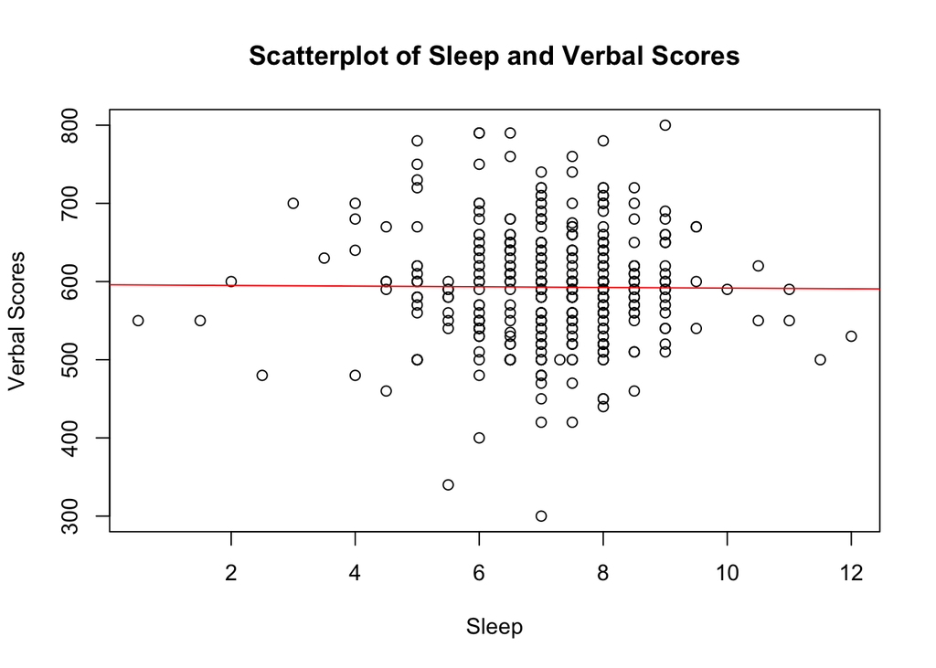

```r
x <- newSurvey_Data$Sleep
y <- newSurvey_Data$Verbal
plot(x, y, main = "Scatterplot of Sleep and Verbal Scores",
     xlab = "Sleep", ylab = "Verbal Scores")

correlation <- cor(x, y)
model <- lm(y ~ x)
# Plot the regression line
abline(model, col = "red")
```

```r
correlation
```

```
## [1] -0.008266078
```

```r
model
```

```
##
## Call:
## lm(formula = y ~ x)
##
## Coefficients:
## (Intercept)            x
##    595.9637      -0.4327
```

for the Analysis below, We will begin by using one-hot encoding to encode some categorical variables:

```r
library(tidyr)
library(dplyr)
newSurvey_Data$Sex <- ifelse(newSurvey_Data$Sex == "male", 1, 0)
newSurvey_Data$Smoke <- ifelse(newSurvey_Data$Smoke == "yes", 1, 0)
newSurvey_Data$Pierced <- ifelse(newSurvey_Data$Pierced == "yes", 1, 0)
newSurvey_Data$Handed <- ifelse(newSurvey_Data$Handed == "right", 1, 0)
newSurvey_Data$Bkfst. <- ifelse(newSurvey_Data$Bkfst. == "yes", 1, 0)
newSurvey_Data$Cell <- ifelse(newSurvey_Data$Cell == "yes", 1, 0)
newSurvey_Data$Dec. <- ifelse(newSurvey_Data$Dec. == "yes", 1, 0)
newSurvey_Data$Live <- ifelse(newSurvey_Data$Live == "on", 1, 0)

# Reshape the data for Color
newSurvey_Data_Color <- newSurvey_Data %>%
  mutate(value = 1) %>%
  pivot_wider(names_from = Color, values_from = value, values_fill = 0)

# Reshape the data for Veg
newSurvey_Data_Eyes <- newSurvey_Data %>%
  mutate(value = 1) %>%
  pivot_wider(names_from = Eyes, values_from = value, values_fill = 0)

newSurvey_Data$Veg. <- ifelse(newSurvey_Data$Veg. == "no", 1,
                      ifelse(newSurvey_Data$Veg. == "some", 2, 3))



newSurvey_Data <- cbind(newSurvey_Data, newSurvey_Data_Color$black, newSurvey_Data_Color$blue, newSurvey_Data_Color$green, newSurvey_Data_Color$orange, newSurvey_Data_Color$red, newSurvey_Data_Color$pink, newSurvey_Data_Color$yellow, newSurvey_Data_Color$purple, newSurvey_Data_Eyes$cl, newSurvey_Data_Eyes$n, newSurvey_Data_Eyes$eg)

names(newSurvey_Data)[34:44] <- c("Black", "Blue", "Green", "Orange", "Red", "Pink",
                                  "Yellow", "Purple", "Closed_Eyes", "Normal_Eyes", "Eyeglasses")

# Remove the original "Color" and "Eyes" columns
newSurvey_Data <- subset(newSurvey_Data, select = -c(Color, Eyes))
newSurvey_Data
```

[output not shown]

[output cut: 1433 more lines]

#5 Examine if you can predict gender from other variables. Use logistic regression to examine which variables among Math, Verbal, WT, HT, Compu, TV, Phone, Shoe, Smoke, and Sibs, which will significantly contribute to predict the gender.

```r
vectorOfDependentVariables <- c("Math", "Verbal", "WT", "HT", "Compu", "TV", "Phone", "Shoe", "Smoke", "Sibs")
# Define the formula
formula <- formula("gender ~ Math + Verbal + WT + HT + Compu + TV + Phone + Shoe + Smoke + Sibs")

# Fit the logistic regression model for each variable
listOfGlms <- lapply(vectorOfDependentVariables, function(x) {
  glm(reformulate(x, "Sex"), data = newSurvey_Data, family = binomial)
})
listOfGlms
```

```
## [[1]]
##
## Call:  glm(formula = reformulate(x, "Sex"), family = binomial, data = newSurvey_Data)
##
## Coefficients:
## (Intercept)         Math
##   -3.255745     0.004401
##
## Degrees of Freedom: 360 Total (i.e. Null);  359 Residual
## Null Deviance:       474.1
## Residual Deviance: 466   AIC: 470
##
## [[2]]
##
## Call:  glm(formula = reformulate(x, "Sex"), family = binomial, data = newSurvey_Data)
##
## Coefficients:
## (Intercept)       Verbal
##    0.601235    -0.001948
##
## Degrees of Freedom: 360 Total (i.e. Null);  359 Residual
## Null Deviance:       474.1
## Residual Deviance: 472.4     AIC: 476.4
##
## [[3]]
##
## Call:  glm(formula = reformulate(x, "Sex"), family = binomial, data = newSurvey_Data)
##
## Coefficients:
## (Intercept)           WT
##   -10.23777      0.06622
##
## Degrees of Freedom: 360 Total (i.e. Null);  359 Residual
## Null Deviance:       474.1
## Residual Deviance: 314.3     AIC: 318.3
##
## [[4]]
##
## Call:  glm(formula = reformulate(x, "Sex"), family = binomial, data = newSurvey_Data)
##
```

[output cut: 64 more lines]

```
## Degrees of Freedom: 360 Total (i.e. Null);  359 Residual
## Null Deviance:       474.1
## Residual Deviance: 471.5     AIC: 475.5
##
## [[10]]
##
## Call:  glm(formula = reformulate(x, "Sex"), family = binomial, data = newSurvey_Data)
##
## Coefficients:
## (Intercept)         Sibs
##    -0.66183      0.05839
##
## Degrees of Freedom: 360 Total (i.e. Null);  359 Residual
## Null Deviance:       474.1
## Residual Deviance: 473.5     AIC: 477.5
```

#6 Try to build a model based on logistic regression and identify which variables among all the available variables which most likely will significantly contribute to predict the gender.

```r
# Fit logistic regression model
mylogit <- glm(sex_fact ~ Math + Verbal + WT + HT + Compu + TV + Phone + Shoe + Smoke + Sibs + MomHT + DadHT + Black + Blue + Green + Orange + Red + Pink + Yellow + Purple + Credits + Year + Live + Exer + Phone + Sleep + Age + MomAge + DadAge + Pierced + Closed_Eyes + Normal_Eyes + Eyeglasses + Earned + Cash + Handed + Bkfst. + Veg. + Cell,
               data = newSurvey_Data, family = "binomial")
# View model summary
summary(mylogit)
```

```
##
## Call:
## glm(formula = sex_fact ~ Math + Verbal + WT + HT + Compu + TV +
##     Phone + Shoe + Smoke + Sibs + MomHT + DadHT + Black + Blue +
##     Green + Orange + Red + Pink + Yellow + Purple + Credits +
##     Year + Live + Exer + Phone + Sleep + Age + MomAge + DadAge +
##     Pierced + Closed_Eyes + Normal_Eyes + Eyeglasses + Earned +
##     Cash + Handed + Bkfst. + Veg. + Cell, family = "binomial",
##     data = newSurvey_Data)
##
## Deviance Residuals:
##     Min       1Q   Median       3Q      Max
## -1.6385  -0.0003   0.0000   0.0000   3.6307
##
## Coefficients: (2 not defined because of singularities)
##               Estimate Std. Error z value Pr(>|z|)
## (Intercept) -10.068307  44.175084  -0.228   0.8197
## Math         -0.001621   0.015001  -0.108   0.9139
## Verbal        0.025386   0.016321   1.555   0.1198
## WT            0.042106   0.074344   0.566   0.5711
## HT            1.565239   1.003456   1.560   0.1188
## Compu        -0.019821   0.012555  -1.579   0.1144
## TV           -0.005010   0.021288  -0.235   0.8140
## Phone        -0.019954   0.026209  -0.761   0.4465
## Shoe          3.359734   1.433091   2.344   0.0191 *
## Smoke         6.943374   5.106434   1.360   0.1739
## Sibs         -0.080017   0.500364  -0.160   0.8729
## MomHT        -0.856080   0.545248  -1.570   0.1164
## DadHT        -1.783086   1.000987  -1.781   0.0749 .
## Black         6.602588   5.027849   1.313   0.1891
## Blue          0.407550   2.321548   0.176   0.8606
## Green        -6.076506   3.991131  -1.523   0.1279
## Orange       -4.850944  54.471558  -0.089   0.9290
## Red          -2.521779   4.089201  -0.617   0.5374
## Pink        -20.920471  47.894804  -0.437   0.6623
## Yellow       -2.650880  75.638244  -0.035   0.9720
## Purple              NA         NA      NA       NA
## Credits       0.144409   0.818371   0.176   0.8599
## Year2         2.379161   2.681244   0.887   0.3749
## Year3         3.115139   3.941677   0.790   0.4293
```

[output cut: 13 more lines]

```
## Cash         -0.034572   0.023289  -1.485   0.1377
## Handed        1.805666   3.117667   0.579   0.5625
## Bkfst.       -8.753697   5.143991  -1.702   0.0888 .
## Veg.          2.591541   1.905665   1.360   0.1739
## Cell         -1.859158   2.392098  -0.777   0.4370
## ---
## Signif. codes:  0 '***' 0.001 '**' 0.01 '*' 0.05 '.' 0.1 ' ' 1
##
## (Dispersion parameter for binomial family taken to be 1)
##
##     Null deviance: 474.066  on 360  degrees of freedom
## Residual deviance:  41.129  on 321  degrees of freedom
## AIC: 121.13
##
## Number of Fisher Scoring iterations: 14
```

Given our results, we found that Shoe Size and Percsing were the best predictors for gender. We came to this conclusion because their values are statistically significant, indicating there is some correlation between them in some way.